# DM_Project_Group27

```python
import numpy as np
import pandas as pd
import matplotlib.pyplot as plt
import seaborn as sns
```

### A. Library Usage Note

```python
import sys
!{sys.executable} -m pip install missingno
import missingno as msno
```

## 1. Data Load and Cleaning Thresholds

- _row_remove*threshold(%)* : Rows with Number of missing values(%) above this threshold will be removed. Initially we set this threshold to 70.
- _drop*threshold(%)* : Columns having values more than this threshold will be preserved, other columns would be dropped. Initially we set this threshold to 60.
- _chunk*size* : We are using a library to draw graph of missing values, this library can draw only 50 columns. so we devided whole columns to chunks of 50

The values in these thresholds are set wisely after so much experiments and cacluations. We'll justify these thresholds in detail in report.

```python
survey_data=pd.read_csv("./data/data.csv",low_memory=False)
data_dictionaary = pd.read_excel('./data/Survey Data Dictionary.xlsx')

row_remove_threshold = 70 #we'll try differnnt threholds to see where we get better results for gender predction
drop_threshold = 60 #only columns with 60% Non-Empty values will be considered
chunk_size =  50 #for drawing graph of missing values
```

## 2. Data Visualization and Cleaning [Row wise]

Most of the people don't fill survey data willingly or skip the input fields, so it's great idea to keep only quality survey data. We have reasonable number of rows 20K+. We are cleaning data based on rows first then we deal with columns.

#### Missing Values Visualization [Original Data]

Note: This cell executes with a waring and take about a minute to execute.

Every graph contains details of missing cells for 50 colums(limitation of graph library). In each columns black horizotal marker indicate a filled value otherwise a white space represents missing value.

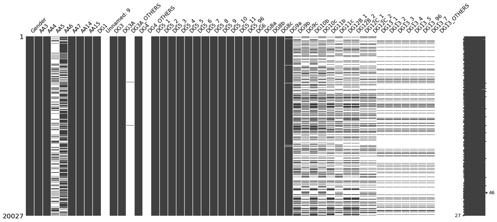

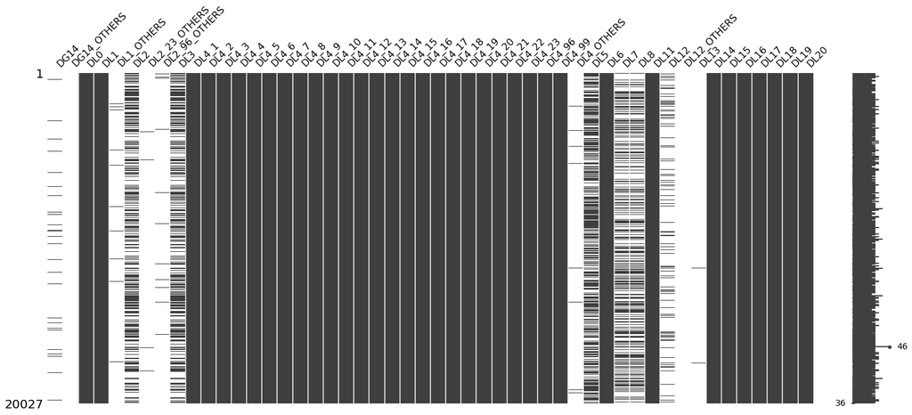

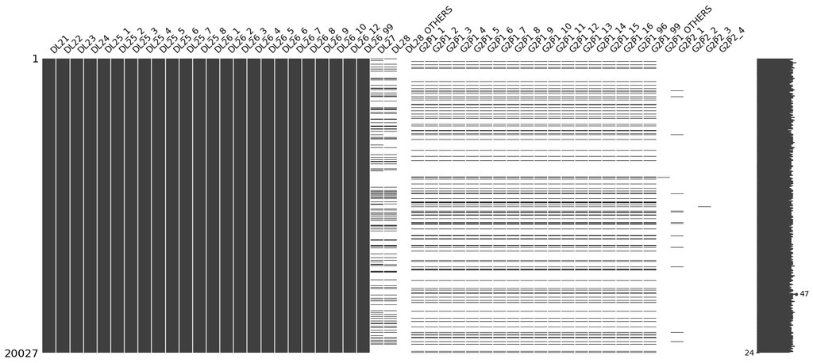

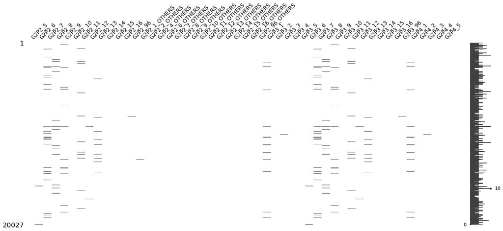

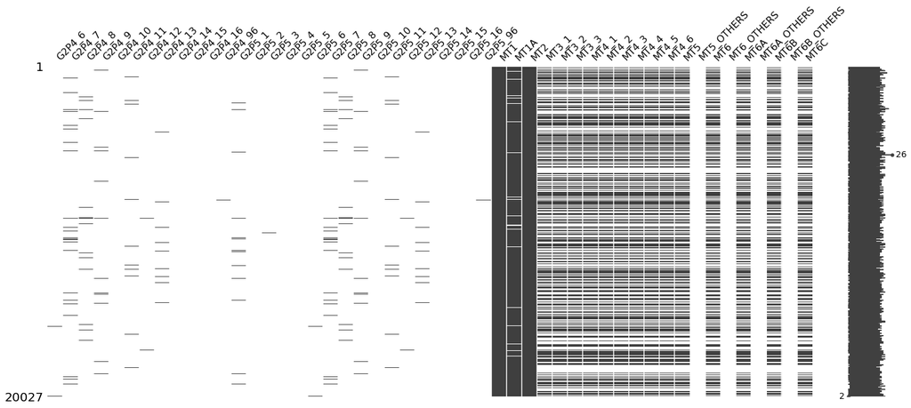

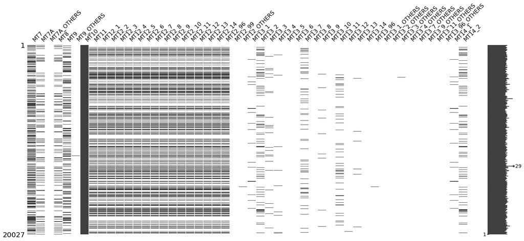

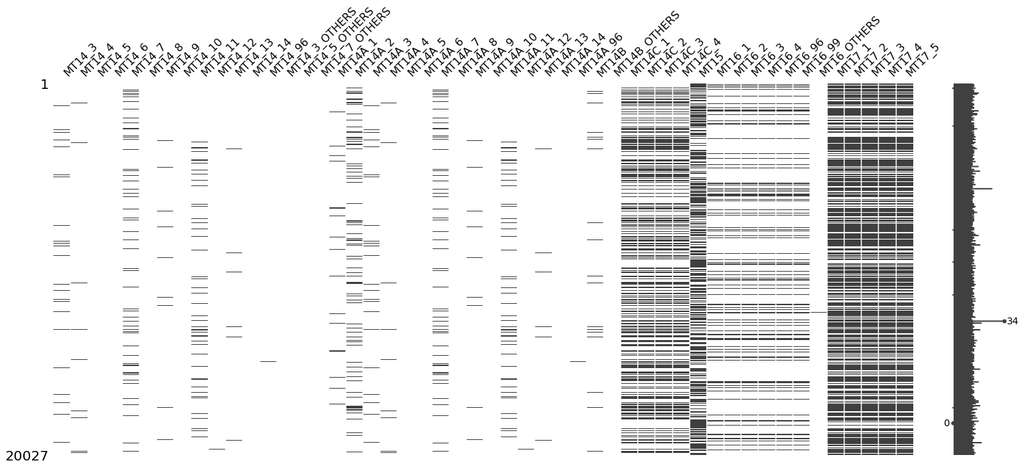

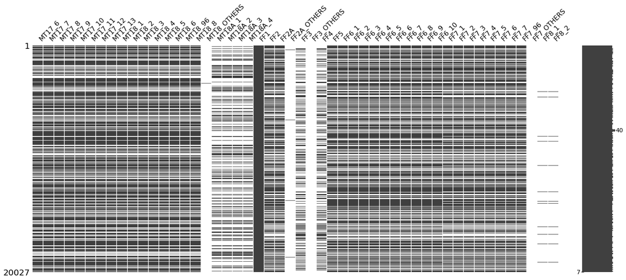

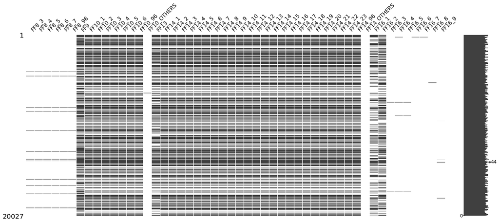

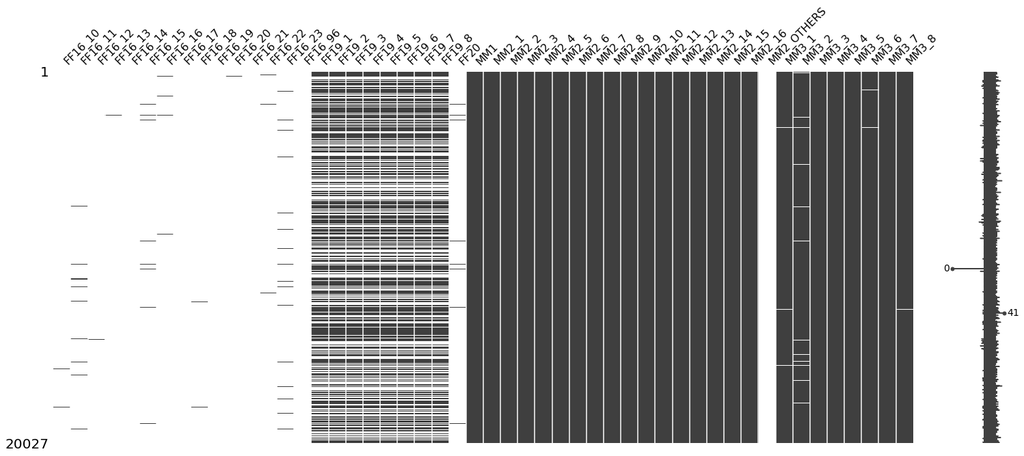

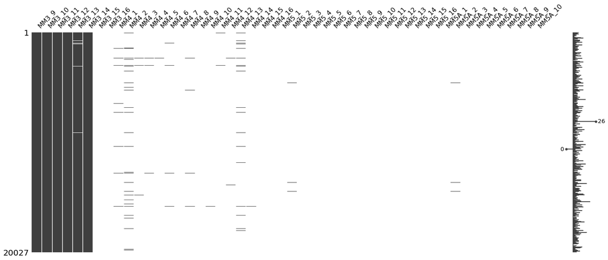

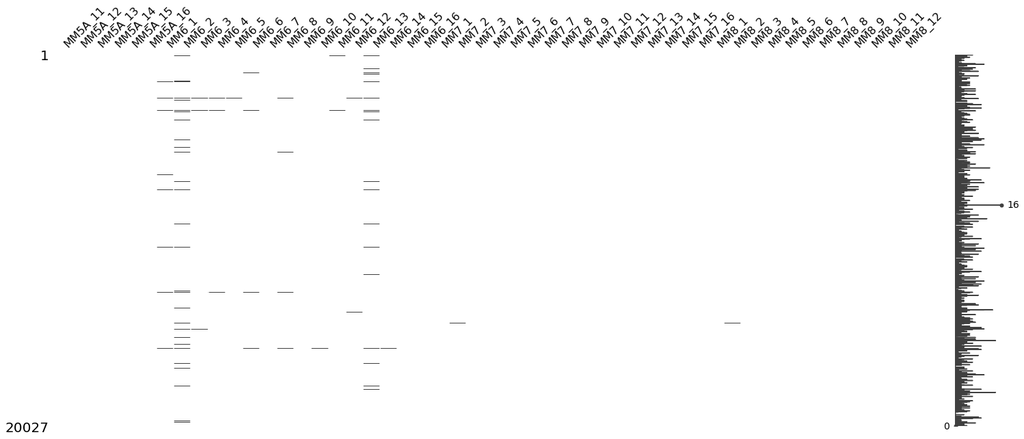

[13 more figures not shown]

```python
cols = survey_data.columns
cols_length = len(cols)
for index in range(0,cols_length,chunk_size):
    set = survey_data[cols[index:index+chunk_size]]
    msno.matrix(set, inline=False)
```

```python
#rows_nulls_percentage: contains the percentage of missing values in every row
rows_nulls_percentage = list((survey_data.isnull().sum(axis=1)/ len(survey_data.columns))*100)

#converting float to into int, so it would be easy to visualize the data
rows_nulls_percentage = [int(i) for i in rows_nulls_percentage]
y_axis = np.zeros(100)


#calculating rows missing percentages.For example row r1, r2, r3 has 1% missing values, then we are storing 3 against 1 percent
#so to say, X number of rows has x% of missing values
for perc in rows_nulls_percentage:
    y_axis[perc] = y_axis[perc] + 1



for percent in range(1, 100):
    if not (y_axis[percent]==0):
        print(y_axis[percent], "\tpeople skiped ",str(percent),"\b% (",str(((percent)*len(survey_data.columns))/100),") fields")
```

```
1.0 	people skiped  43 % ( 531.05 ) fields
1.0 	people skiped  46 % ( 568.1 ) fields
1.0 	people skiped  47 % ( 580.45 ) fields
2.0 	people skiped  48 % ( 592.8 ) fields
2.0 	people skiped  49 % ( 605.15 ) fields
8.0 	people skiped  50 % ( 617.5 ) fields
4.0 	people skiped  51 % ( 629.85 ) fields
13.0 	people skiped  52 % ( 642.2 ) fields
17.0 	people skiped  53 % ( 654.55 ) fields
22.0 	people skiped  54 % ( 666.9 ) fields
23.0 	people skiped  55 % ( 679.25 ) fields
16.0 	people skiped  56 % ( 691.6 ) fields
30.0 	people skiped  57 % ( 703.95 ) fields
49.0 	people skiped  58 % ( 716.3 ) fields
58.0 	people skiped  59 % ( 728.65 ) fields
126.0 	people skiped  60 % ( 741.0 ) fields
204.0 	people skiped  61 % ( 753.35 ) fields
336.0 	people skiped  62 % ( 765.7 ) fields
530.0 	people skiped  63 % ( 778.05 ) fields
932.0 	people skiped  64 % ( 790.4 ) fields
1700.0 	people skiped  65 % ( 802.75 ) fields
1983.0 	people skiped  66 % ( 815.1 ) fields
1675.0 	people skiped  67 % ( 827.45 ) fields
1466.0 	people skiped  68 % ( 839.8 ) fields
1222.0 	people skiped  69 % ( 852.15 ) fields
1226.0 	people skiped  70 % ( 864.5 ) fields
1361.0 	people skiped  71 % ( 876.85 ) fields
1240.0 	people skiped  72 % ( 889.2 ) fields
962.0 	people skiped  73 % ( 901.55 ) fields
1185.0 	people skiped  74 % ( 913.9 ) fields
1207.0 	people skiped  75 % ( 926.25 ) fields
1186.0 	people skiped  76 % ( 938.6 ) fields
1196.0 	people skiped  77 % ( 950.95 ) fields
43.0 	people skiped  78 % ( 963.3 ) fields
```

### 2.1. Survey Data Rows Fill Chart

As described in above cell, we are calculating rows missing percentages.For example row r1, r2, r3 has 1% missing values, then we are storing 3 against 1 percent. So to say, X number of rows has x% of missing values

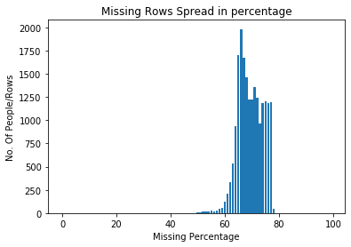

```python
plt.bar(range(len(y_axis)),y_axis)
plt.title('Missing Rows Spread in percentage')
plt.ylabel("No. Of People/Rows")
plt.xlabel("Missing Percentage")
```

### 2.2. Survey Data Rows Fill Chart [More Precise]

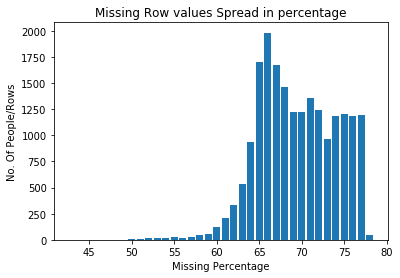

```python
# more precise visualization of above graph
dd = pd.Index(rows_nulls_percentage)
p_c = (dd.value_counts(sort=False, ascending=True))
#print(p_c)


unique_percentages  = dd.unique()
unique_percentages.sort_values()

y_a = []
for u_per in unique_percentages:
    val = (dd[dd == u_per].value_counts())
    y_a.append(int(val))

y_a,unique_percentages
plt.bar(unique_percentages, y_a)
plt.title('Missing Row values Spread in percentage')
plt.ylabel("No. Of People/Rows")
plt.xlabel("Missing Percentage")
```

```python
for index in range(len(unique_percentages)):
    print(y_a[index],"\tPeople skipped ",unique_percentages[index],"\b% fields")
```

```
1186 	People skipped  76 % fields
1222 	People skipped  69 % fields
1983 	People skipped  66 % fields
1361 	People skipped  71 % fields
1207 	People skipped  75 % fields
1196 	People skipped  77 % fields
530 	People skipped  63 % fields
1675 	People skipped  67 % fields
1466 	People skipped  68 % fields
962 	People skipped  73 % fields
1226 	People skipped  70 % fields
1700 	People skipped  65 % fields
1240 	People skipped  72 % fields
932 	People skipped  64 % fields
1185 	People skipped  74 % fields
```

[output cut: 19 more lines]

### 2.3. Rows Removing/Droping

In the below cell indeces of the rows that doesn't match our filter criteria are calculated and then rows are dropped.

```python
#survey_data=pd.read_csv("./data/data.csv",low_memory=False)


rows_indeces_to_remove = []
for index, perc in enumerate(rows_nulls_percentage):
    if(perc>row_remove_threshold):
        rows_indeces_to_remove.append(index)


print(len(rows_indeces_to_remove),"rows out of ",(survey_data.shape[0]),"will be removed with threshold",row_remove_threshold,"\b%")
#print(rows_nulls_percentage)

survey_data.drop(survey_data.index[rows_indeces_to_remove], inplace=True)
```

```
8380 rows out of  20027 will be removed with threshold 70 %
```

### 2.4. Shape of data set after removing rows

```python
survey_data.shape
```

```
(11647, 1235)
```

## 3. Data Visualization and Cleaning [Column wise]

#### Missing Values Visualization [After dropping rows]

Note: This cell executes with a waring and take about a minute to execute.

Every graph contains details of missing cells for 50 colums(limitation of graph library). In each columns black horizotal marker indicate a filled value otherwise a white space represents missing value.

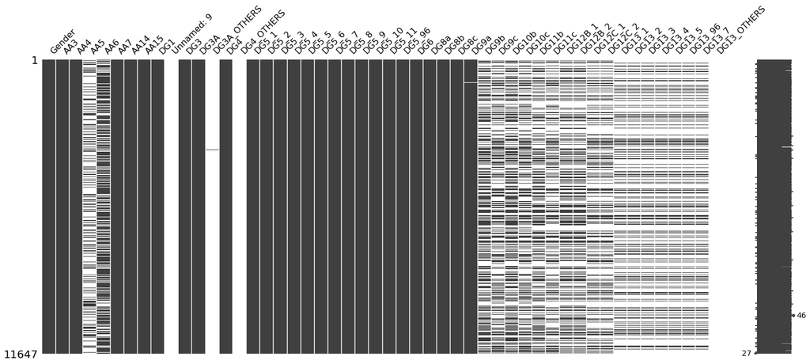

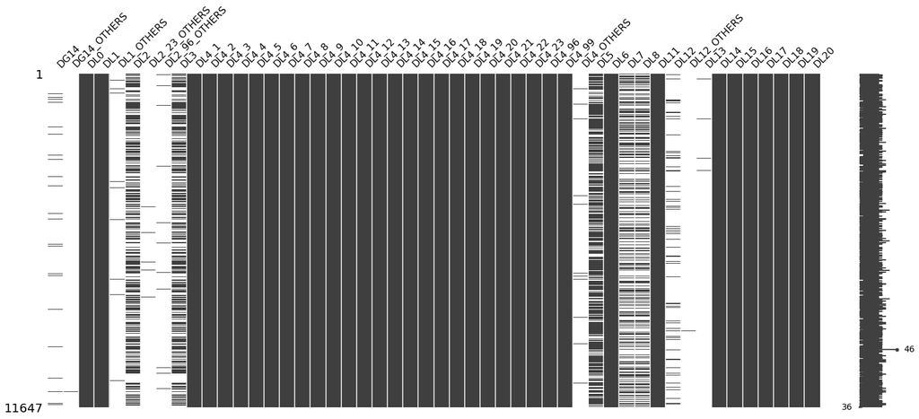

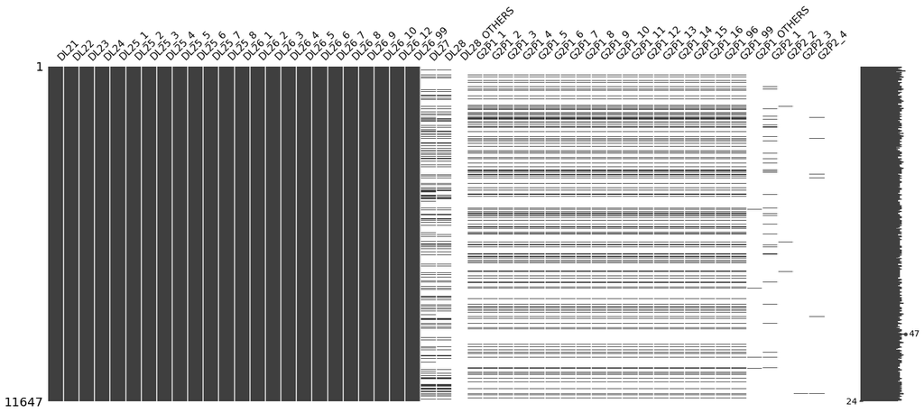

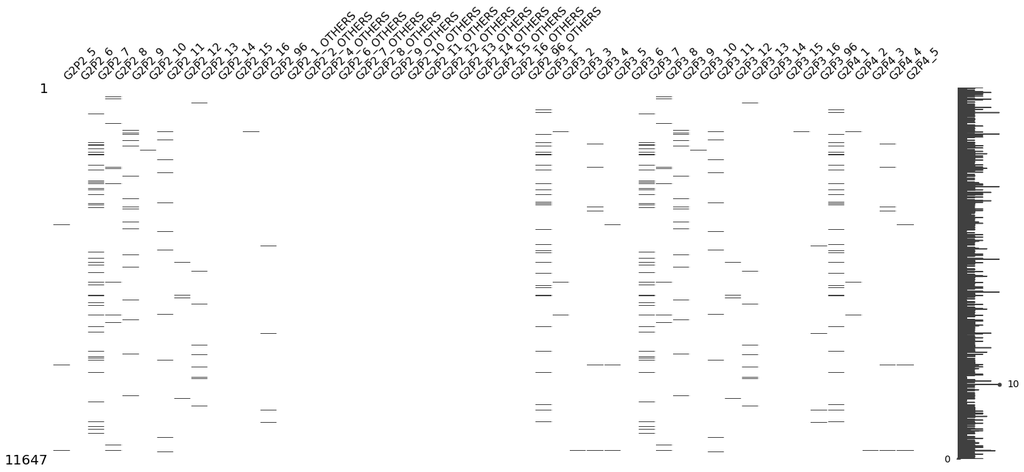

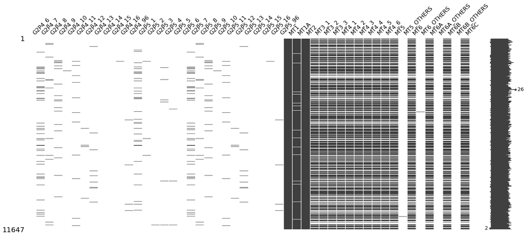

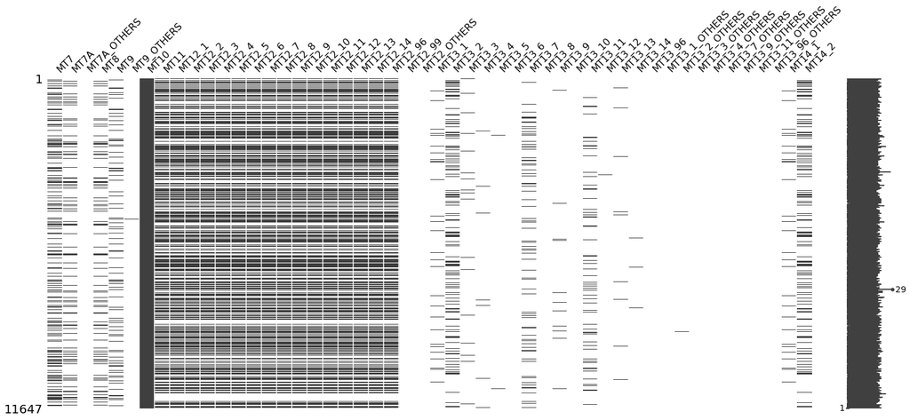

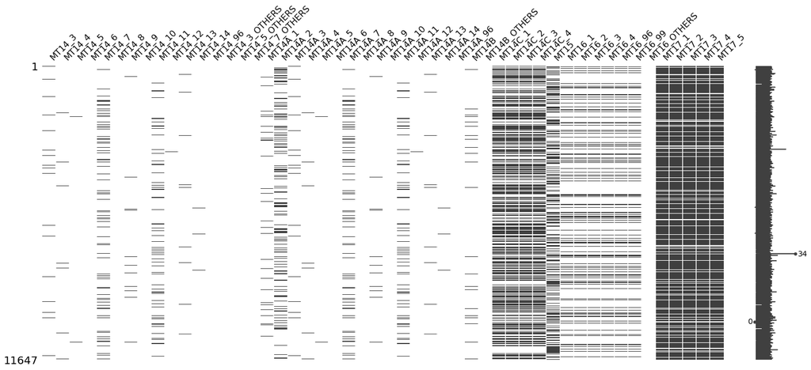

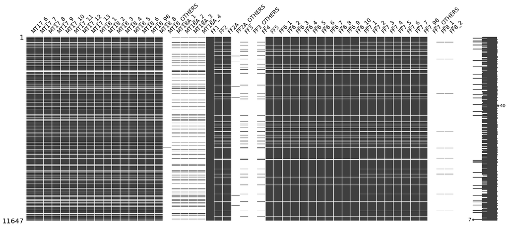

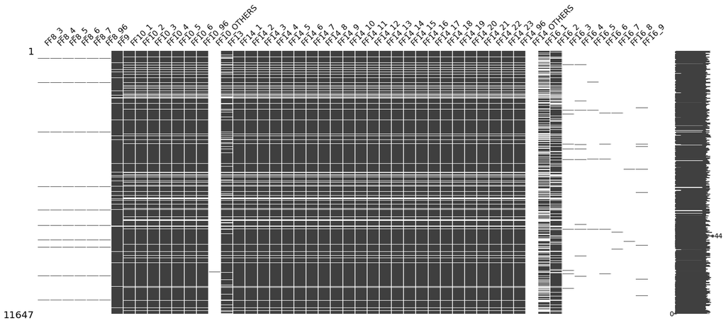

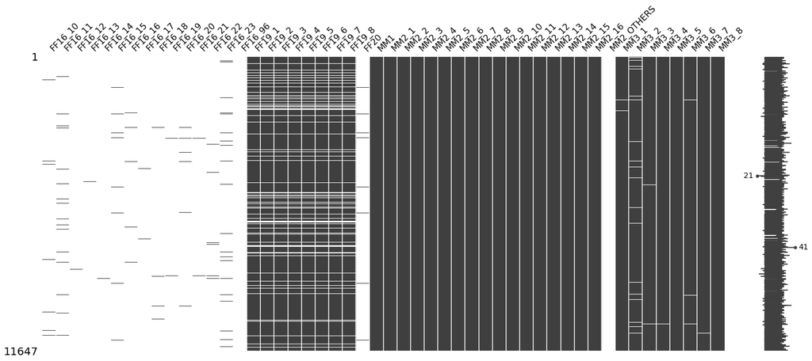

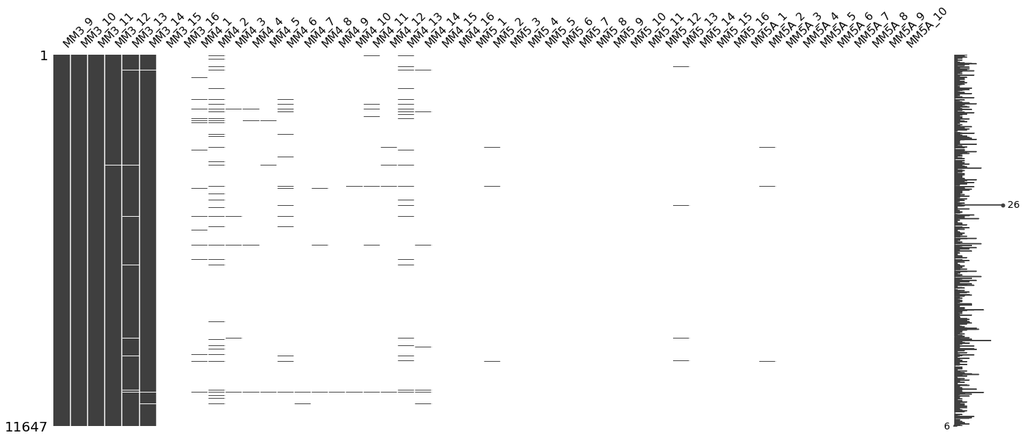

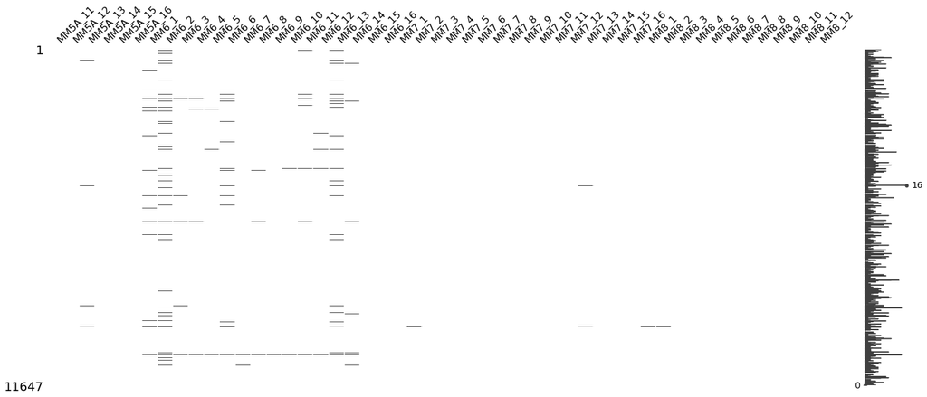

[13 more figures not shown]

```python
cols = survey_data.columns
cols_length = len(cols)
for index in range(0,cols_length,chunk_size):
    set = survey_data[cols[index:index+chunk_size]]
    msno.matrix(set, inline=False)
```

### B. Issue: Dictionary mismatch

data.csv hay 1235 columns but we have details of 1105 columns in dictionary. In the cell below, columns that are in our data.csv (UNCLEANED), but not dictionary. We didn't remove them just becuase they have missing, we handled missing columns nicely but after dropping columns those do not match our criteria.

```python
cols_in_data = survey_data.columns
print("Columns in Data.csv", len(cols_in_data))

cols_in_dic = len(data_dictionaary)
print("Columns in Dictionary.xlsx", cols_in_dic)

columns_in_dictionary = list(data_dictionaary['Column Name'])


missing_cols_in_data = [] #these are the columns which are in dictionary but not used in data
for col in columns_in_dictionary :
    if col not in cols_in_data:
        #print(col)
        missing_cols_in_data.append(str(col))

print("Columns in dictionary but not in data.csv", len(missing_cols_in_data))

missing_cols_in_dic = []
for col in cols_in_data:
    if col not in columns_in_dictionary:
        #print(col)
        missing_cols_in_dic.append(str(col))

print(len(cols_in_data),"-(",cols_in_dic,"-",len(missing_cols_in_data),")=",len(missing_cols_in_dic))
print("\nFollowing are ",len(missing_cols_in_dic)," columns in our data for which there's no information in dictionary:\n\n",missing_cols_in_dic)
#columns_in_dictionary
```

```
Columns in Data.csv 1235
Columns in Dictionary.xlsx 1105
Columns in dictionary but not in data.csv 30
1235 -( 1105 - 30 )= 160

Following are  160  columns in our data for which there's no information in dictionary:

 ['AA4', 'AA7', 'AA14', 'AA15', 'Unnamed: 9', 'DG3A_OTHERS', 'DG4_OTHERS', 'DG10b', 'DG10c', 'DG11b', 'DG11c', 'DG13_OTHERS', 'DG14_OTHERS', 'DL1_OTHERS', 'DL2_23_OTHERS', 'DL2_96_OTHERS', 'DL4_96', 'DL4_99', 'DL4_OTHERS', 'DL12_OTHERS', 'DL14', 'DL28_OTHERS', 'G2P1_OTHERS', 'G2P2_96', 'G2P2_1_OTHER…
```

### 3.1. In the following cell, columns those don't match our criteria will be dropped

```python
all_columns = survey_data.columns
data_size_N = survey_data.shape[0]
cols_with_missing_values_count = 0
complete_col_count = 0
null_col_count = 0
should_drop_count = 0


#drop_threshold = 60

columns_to_drop = []

#count the columns where even 1 row is missing
for col in all_columns:
    current_col = survey_data[col]
    missing_values_count = current_col.isnull().sum()
    non_empty_values_percentage = ((data_size_N - missing_values_count)/data_size_N)*100
    if(missing_values_count==0):
        complete_col_count+=1
    if(missing_values_count==data_size_N):
        null_col_count+=1
    if non_empty_values_percentage <  drop_threshold:
        #print(non_empty_values_percentage, data_size_N,missing_values_count, col)
        should_drop_count += 1
        columns_to_drop.append(col)
        #print(col)
    if missing_values_count > 0:
        cols_with_missing_values_count += 1
        #print('Column ',col, ' has',missing_values_count,' missing values' )

remaining_columns_count = len(all_columns)-should_drop_count

print('Total Columns in data',len(all_columns),'\nColumns with missing values',cols_with_missing_values_count,'\nColumns with completely filled values',complete_col_count, "\nColumns with all missing values",null_col_count,"\nTotal",should_drop_count,"columns should be dropped with threshold",drop_threshold,"\b%\nRemaining Columns",remaining_columns_count)
```

```
Total Columns in data 1235
Columns with missing values 997
Columns with completely filled values 238
Columns with all missing values 55
Total 849 columns should be dropped with threshold 60 %
Remaining Columns 386
```

### 3.2. Shape of Dataset after Removing Columns

```python
data_filtered = survey_data.drop(columns_to_drop, axis=1)
data_filtered.shape
```

```
(11647, 386)
```